# Hadi Babalou - 810199380

Artificial Intelligence - CA#03: *Multilayer Perceptron* - Spring 2023 \ In this notebook, first we will implement a [Multilayer Perceptron](https://en.wikipedia.org/wiki/Multilayer_perceptron) from scratch and then we will use it to classify moons dataset. \ Then we will use pytorch to implement a multilayer perceptron and do sentiement analysis on IMDB comments dataset.

## 1. Multilayer Perceptron from scratch

### 1.1. Some utilities and dataset for Part 2

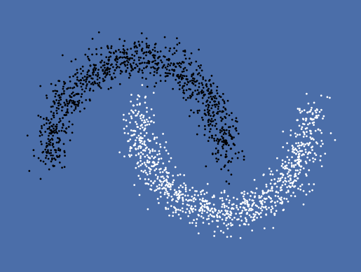

```python
import numpy as np
import matplotlib.pyplot as plt
import pandas as pd
import copy

# Plot the dataset
def plot_data(ax, X, Y):
    plt.axis('off')
    ax.scatter(X[:, 0], X[:, 1], s=1, c=Y, cmap='bone')

from sklearn.datasets import make_moons
X, y = make_moons(n_samples=2000, noise=0.1)

%matplotlib inline
x_min, x_max = -1.5, 2.5
y_min, y_max = -1, 1.5
fig, ax = plt.subplots(1, 1, facecolor='#4B6EA9')
ax.set_xlim(x_min, x_max)
ax.set_ylim(y_min, y_max)
plot_data(ax, X, y)
plt.show()
```

```python
# Define the grid on which we will evaluate our classifier
xx, yy = np.meshgrid(np.arange(x_min, x_max, .1),
                     np.arange(y_min, y_max, .1))

to_forward = np.array(list(zip(xx.ravel(), yy.ravel())))

# plot the decision boundary of our classifier
def plot_decision_boundary(ax, X, Y, classifier):
    # forward pass on the grid, then convert to numpy for plotting
    Z = classifier.forward(to_forward)
    Z = Z.reshape(xx.shape)

    # plot contour lines of the values of our classifier on the grid
    ax.contourf(xx, yy, Z>0.5, cmap='Blues')

    # then plot the dataset
    plot_data(ax, X,Y)
```

### 1.2. MLP in numpy

Here we code our implementation of the ReLU) activation and the [Sigmoid](https://en.wikipedia.org/wiki/Sigmoid_function).

```python
class MyReLU(object):
    def forward(self, x):
        # the relu is y_i = max(0, x_i)
        self.fx = np.maximum(0, x)
        return self.fx

    def backward(self, grad_output):
        # the result is 1 for the grad_outputs that were above 0, 0 elsewhere
        grad = np.where(self.fx > 0, 1, 0)
        return grad_output * grad

    def step(self, learning_rate):
        # no need to do anything here, since ReLU has no parameters
        return
```

```python
class MySigmoid(object):
    def forward(self, x):
        # the sigmoid is y_i = 1./(1+exp(-x_i))
        self.x = x
        numerator = 1.
        denominator = 1. + np.exp(-x)
        self.fx = numerator / denominator
        return self.fx

    def backward(self, grad_output):
        # the partial derivative is e^-x / (e^-x + 1)^2
        # which is equal to fx * (1 - fx)
        out = grad_output * self.fx * (1 - self.fx)
        return out

    def step(self, learning_rate):
        # no need to do anything here since Sigmoid has no parameters
        return
```

Probably a good time to test our functions...

```python
test_relu = MyReLU()
test_relu.forward([0, -1, 0.5, -0.5, 0.8, 1])
```

```
array([0. , 0. , 0.5, 0. , 0.8, 1. ])
```

```python
test_relu.backward(np.ones(1))
```

```
array([0., 0., 1., 0., 1., 1.])
```

```python
test_sig = MySigmoid()

test_sig.forward(np.ones(1))
```

```
array([0.73105858])
```

```python
test_sig.backward(np.ones(1))
```

```
array([0.19661193])
```

A bit more complicated, we need now to implement our linear layer i.e. multiplication by a matrix W and summing with a bias b.

```python
class MyLinear(object):
    def __init__(self, n_input, n_output):
        # initialize two random matrices for W and b (use np.random.randn)
        self.W = np.random.randn(n_input, n_output)
        self.b = np.random.randn(n_output)

    def forward(self, x):
        # save a copy of x, we'll need it for the backward
        # return Wx + b
        self.x = copy.deepcopy(x)
        self.fx = np.dot(x, self.W) + self.b
        return self.fx

    def backward(self, grad_output):
        # y_i = \sum_j W_{i,j} x_j + b_i
        # d y_i / d W_{i, j} = x_j
        # d loss / d y_i = grad_output[i]
        # so d loss / d W_{i,j} = x_j * grad_output[i]  (by the chain rule)
        dC_dW = np.outer(self.x, grad_output)

        # d y_i / d b_i = 1
        # d loss / d y_i = grad_output[i]
        # so d loss / d b_i = grad_output[i]  (by the chain rule)
        dC_db = grad_output

        # now we need to compute the gradient with respect to x to continue the back propagation
        # d y_i / d x_j = W_{i, j}
        # to compute the gradient of the loss, we have to sum over all possible y_i in the chain rule
        # d loss / d x_j = \sum_i (d loss / d y_i) (d y_i / d x_j)
        #                = \sum_i grad_output[i] * W_{i, j}
        dC_dx = np.dot(grad_output, self.W.T)

        self.dW = dC_dW
        self.db = dC_db
        return dC_dx


    def step(self, learning_rate):
        # update self.W and self.b in the opposite direction of the stored gradients, for learning_rate
        self.W -= learning_rate * self.dW
        self.b -= learning_rate * self.db
```

Now we should code our network. Note that with a Sigmoid layer, we should use the Binary Cross Entropy (BCE) loss.

```python
class Sequential(object):
    def __init__(self):
        # Specify your model's Architecture here (Use your Linear and Activation Functions)

        self.layers = []
        self.layers.append(MyLinear(2, 64))
        # self.layers.append(MySigmoid())
        self.layers.append(MyReLU())
        self.layers.append(MyLinear(64, 64))
        # self.layers.append(MySigmoid())
        self.layers.append(MyReLU())
        # self.layers.append(MyLinear(64, 64))
        # self.layers.append(MySigmoid())
        # self.layers.append(MyReLU())
        self.layers.append(MyLinear(64, 1))
        self.layers.append(MySigmoid())
        # self.layers.append(MyReLU())


    def forward(self, x):
        # apply each layer sequentially
        for layer in self.layers:
            x = layer.forward(x)
        return x


    def compute_loss(self, out, label):
        # use the BCE loss
        # -(label * log(output) + (1-label) * log(1-output))
        # save the gradient, and return the loss
        # beware of dividing by zero in the gradient.
        # split the computation in two cases, one where the label is 0 and another one where the label is 1
        # add a small value (1e-10) to the denominator

        epsilon = 1e-10
        loss = -label * np.log(out + epsilon) - (1 - label) * np.log(1 - out + epsilon)
        self.grad = -label / (out + epsilon) + (1 - label) / (1 - out + epsilon)

        treshold = 0.01
        prob = np.random.uniform(0, 1)
        if prob < treshold:
            print('\r', end='')
            print(100 * ' ', end='')
            print('\r', end='')
            print(f'Loss: {loss.mean():.4f},\tlabel: {label},\tpredicted: {np.where(out > 0.5, 1, 0)},\tout: {out}', end='')

        return loss


    def backward(self):
        # apply backprop sequentially, starting from the gradient of the loss
        grad = self.grad
        for layer in reversed(self.layers):
            grad = layer.backward(grad)
        return grad


    def step(self, learning_rate):
        # take a gradient step for each layers
        for layer in self.layers:
            layer.step(learning_rate)
        return
```

```python
# define your network with your Sequential Class
network = Sequential()
```

```python
losses = []
grads = []
learning_rate = 1e-3
epochs = 20

for epoch in range(epochs):
    for it in range(len(X)):
        # pick a random example idx
        idx = np.random.randint(len(X))

        # select the corresponding example and label
        example = X[idx]
        label = y[idx]

        # do a forward pass on the example
        out = network.forward(example)
        # print(out)

        # compute the loss according to your output and the label
        loss = network.compute_loss(out, label)
        losses.append(loss)

        # backward pass
        network.backward()

        # gradient step
        network.step(learning_rate)
```

```
Loss: 0.0000,	label: 1,	predicted: [1],	out: [0.99999994]
```

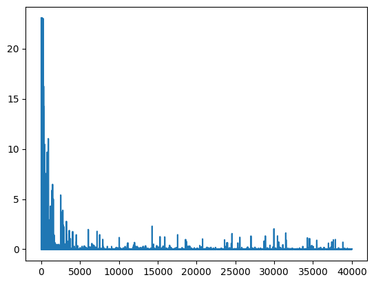

```python
%matplotlib inline
plt.plot(losses)
plt.show()
```

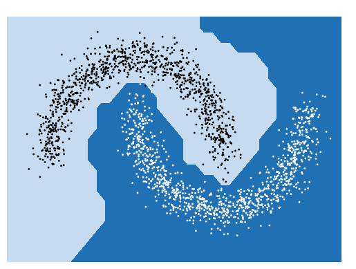

```python
fig, ax = plt.subplots(1, 1)
ax.set_xlim(x_min, x_max)
ax.set_ylim(y_min, y_max)
plot_decision_boundary(ax, X, y, network)
fig.canvas.draw()
```

## 2. Load & Preprocess the IMDB Dataset

In this section, we are to read and load the provided `csv` file, and perform the preprocessing steps.

```python
comments_df = pd.read_csv('imdb_dataset.csv')
# from google.colab import drive
# drive.mount('/content/drive', force_remount=True)
# comments_df = pd.read_csv('/content/drive/MyDrive/Datasets/imdb_dataset.csv')
```

```python
comments_df.head(n=10)
```

|  | review | sentiment |
| --- | --- | --- |
| 0 | One of the other reviewers has mentioned that ... | positive |
| 1 | A wonderful little production. <br /><br />The... | positive |
| 2 | I thought this was a wonderful way to spend ti... | positive |
| 3 | Basically there's a family where a little boy ... | negative |
| 4 | Petter Mattei's "Love in the Time of Money" is... | positive |
| 5 | Probably my all-time favorite movie, a story o... | positive |
| 6 | I sure would like to see a resurrection of a u... | positive |
| 7 | This show was an amazing, fresh & innovative i... | negative |
| 8 | Encouraged by the positive comments about this... | negative |
| 9 | If you like original gut wrenching laughter yo... | positive |

```python
comments_df.info()
```

```
<class 'pandas.core.frame.DataFrame'>
RangeIndex: 50000 entries, 0 to 49999
Data columns (total 2 columns):
 #   Column     Non-Null Count  Dtype
---  ------     --------------  -----
 0   review     50000 non-null  object
 1   sentiment  50000 non-null  object
dtypes: object(2)
memory usage: 781.4+ KB
```

```python
comments_df.describe()
```

|  | review | sentiment |
| --- | --- | --- |
| count | 50000 | 50000 |
| unique | 49582 | 2 |
| top | Loved today's show!!! It was a variety and not... | positive |
| freq | 5 | 25000 |

```python
comments_df['sentiment'].value_counts()
```

```
positive    25000
negative    25000
Name: sentiment, dtype: int64
```

```python
import nltk
from bs4 import BeautifulSoup
import re
from sklearn.preprocessing import LabelEncoder
from sklearn.feature_extraction.text import TfidfVectorizer
```

```python
def strip_html_tags(text):
    soup = BeautifulSoup(text, "html.parser")
    stripped_text = soup.get_text(separator=" ")
    return stripped_text
```

```python
def remove_between_square_brackets(text):
    return re.sub('\[[^]]*\]', '', text)
```

```python
def remove_special_characters(text):
    pattern = r'[^a-zA-z0-9\s]'
    text = re.sub(pattern, '', text)
    return text
```

### Stemming & Lemmatization

Stemming and lemmatization are techniques used in natural language processing (NLP) to reduce words to their base or root form. Both approaches are used to normalize and standardize words, improving text analysis and information retrieval. While they have a similar goal, there are differences between them.

Stemming involves reducing words to their stems by removing suffixes or prefixes. For example, the word "running" would be stemmed to "run." Stemming typically uses heuristic rules to chop off affixes, which may not always result in a linguistically valid word. Stemming algorithms are generally simpler and faster compared to lemmatization.

Lemmatization, on the other hand, aims to reduce words to their base or dictionary form, known as the lemma. It takes into account the word's context and morphological analysis. For instance, the word "running" would be lemmatized to "run," but also the word "ran" would be lemmatized to "run." Lemmatization algorithms use more complex linguistic rules and often rely on part-of-speech tagging to produce accurate lemmas.

The advantages of stemming include simplicity and speed. Stemming algorithms are typically more straightforward and faster to implement, making them suitable for tasks that prioritize efficiency over linguistic accuracy. Stemming can be useful in applications like search engines or text classification, where speed is crucial.

Lemmatization, on the other hand, provides more accurate results by considering the context and producing valid lemmas. It offers a deeper understanding of the language, which can be valuable in applications like machine translation, information retrieval, or sentiment analysis. Lemmatization can also help in maintaining the interpretability of the text during analysis.

In summary, stemming is a simpler and faster process that reduces words to their base form by removing affixes, while lemmatization provides more accurate results by considering the word's context and producing valid lemmas. Stemming is advantageous for speed and simplicity, while lemmatization offers linguistic accuracy and deeper language understanding. The choice between the two depends on the specific NLP task and the trade-off between efficiency and accuracy.

```python
def stemmer(text):
    ps = nltk.porter.PorterStemmer()
    text = ' '.join([ps.stem(word) for word in text.split()])
    return text
```

```python
def lemmatize(text):
    wnl = nltk.WordNetLemmatizer()
    text = ' '.join([wnl.lemmatize(word) for word in text.split()])
    return text
```

```python
nltk.download('stopwords')
```

```python
tokenizer = nltk.tokenize.ToktokTokenizer()
stopwords_list = nltk.corpus.stopwords.words('english')

def remove_stopwords(text, is_lower_case=False, tokenizer=tokenizer, stopwords_list=stopwords_list):
    tokens = tokenizer.tokenize(text)
    tokens = [token.strip() for token in tokens]
    filtered_text = ' '.join([token for token in tokens if token not in stopwords_list])
    return filtered_text
```

```python
modified_comments_df = comments_df.copy()
```

```python
modified_comments_df['review'] = modified_comments_df['review'].apply(strip_html_tags)
modified_comments_df['review'] = modified_comments_df['review'].apply(remove_between_square_brackets)
modified_comments_df['review'] = modified_comments_df['review'].apply(remove_special_characters)
modified_comments_df['review'] = modified_comments_df['review'].apply(remove_stopwords)
modified_comments_df['review'] = modified_comments_df['review'].apply(stemmer)
# modified_comments_df['review'] = modified_comments_df['review'].apply(lemmatize)
```

```python
modified_comments_df.head(n=10)
```

|  | review | sentiment |
| --- | --- | --- |
| 0 | one review mention watch 1 oz episod youll hoo... | positive |
| 1 | a wonder littl product the film techniqu unass... | positive |
| 2 | i thought wonder way spend time hot summer wee... | positive |
| 3 | basic there famili littl boy jake think there ... | negative |
| 4 | petter mattei love time money visual stun film... | positive |
| 5 | probabl alltim favorit movi stori selfless sac... | positive |
| 6 | i sure would like see resurrect date seahunt s... | positive |
| 7 | thi show amaz fresh innov idea 70 first air th... | negative |
| 8 | encourag posit comment film i look forward wat... | negative |
| 9 | if like origin gut wrench laughter like movi i... | positive |

```python
encoder = LabelEncoder()
modified_comments_df['sentiment'] = encoder.fit_transform(modified_comments_df['sentiment'])
```

```python
modified_comments_df.head(n=10)
```

|  | review | sentiment |
| --- | --- | --- |
| 0 | one review mention watch 1 oz episod youll hoo... | 1 |
| 1 | a wonder littl product the film techniqu unass... | 1 |
| 2 | i thought wonder way spend time hot summer wee... | 1 |
| 3 | basic there famili littl boy jake think there ... | 0 |
| 4 | petter mattei love time money visual stun film... | 1 |
| 5 | probabl alltim favorit movi stori selfless sac... | 1 |
| 6 | i sure would like see resurrect date seahunt s... | 1 |
| 7 | thi show amaz fresh innov idea 70 first air th... | 0 |
| 8 | encourag posit comment film i look forward wat... | 0 |
| 9 | if like origin gut wrench laughter like movi i... | 1 |

### TF-IDF

Term Frequency-Inverse Document Frequency (TF-IDF) is a numerical statistic that reflects the importance of a term in a document within a collection of documents. It combines two components: term frequency (TF) and inverse document frequency (IDF).

1. Term Frequency (TF): Term Frequency represents the frequency of a term (word) within a document. It measures how often a term occurs in a particular document. The idea behind TF is that the more frequently a term appears in a document, the more important it is to that document. TF is typically calculated by counting the number of occurrences of a term within a document.
2. Inverse Document Frequency (IDF): Inverse Document Frequency measures the rarity or uniqueness of a term in a collection of documents. It calculates the inverse of the frequency of the term across all the documents. The IDF component helps to diminish the weight of terms that are common across all documents and amplify the weight of terms that are rare and occur in only a few documents. IDF is typically calculated as the logarithm of the total number of documents divided by the number of documents containing the term.

The TF-IDF score of a term in a document is obtained by multiplying the term frequency (TF) of the term in the document by the inverse document frequency (IDF) of the term across the document collection. This score provides a measure of how relevant a term is to a particular document in the context of the entire document collection. Generally, higher TF-IDF scores indicate that a term is more important to a specific document.

TF-IDF is often used in various natural language processing (NLP) tasks such as text classification, keyword extraction, information retrieval, and document clustering. It helps to identify important terms and reduce the impact of common words that appear in many documents, allowing for more meaningful analysis and representation of textual data.

```python
nltk.download('punkt')
```

```python
final_df = modified_comments_df.copy()

tfid_vectorizer = TfidfVectorizer(max_features=5000, tokenizer=nltk.word_tokenize, stop_words='english', ngram_range=(1,3), max_df=0.75, min_df=5, use_idf=True, smooth_idf=True, lowercase=True)
tfid_matrix = tfid_vectorizer.fit_transform(final_df['review'])
```

```python
from sklearn.model_selection import train_test_split

train_ratio = 0.8

X = tfid_matrix
y = final_df['sentiment']
X_train, X_test, y_train, y_test = train_test_split(X, y, train_size=train_ratio, random_state=18)
```

```python
X_train.shape, X_test.shape, y_train.shape, y_test.shape
```

```
((40000, 5000), (10000, 5000), (40000,), (10000,))
```

### A random positive and negative review

```python
while True:
    index = np.random.randint(X_train.shape[0])
    if y_train.iloc[index] == 1:
        print("positive review")
        print("raw:", comments_df.iloc[index]['review'])
        print("modified:", modified_comments_df.iloc[index]['review'])
        break
```

[output not shown]

```python
while True:
    index = np.random.randint(X_train.shape[0])
    if y_train.iloc[index] == 0:
        print("negative review")
        print("raw:", comments_df.iloc[index]['review'])
        print("modified:", modified_comments_df.iloc[index]['review'])
        break
```

[output not shown]

### Data Distribution

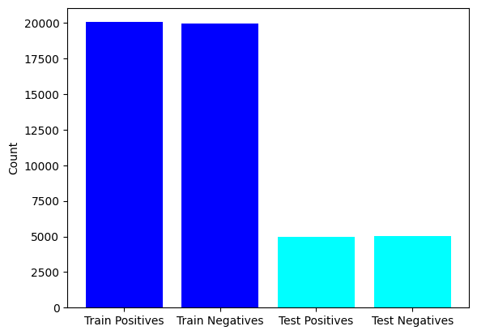

```python
train_positives = y_train.value_counts()[1]
train_negatives = y_train.value_counts()[0]
test_positives = y_test.value_counts()[1]
test_negatives = y_test.value_counts()[0]

# bar plot of the 4 values
fig, ax = plt.subplots(1, 1)
ax.bar(['Train Positives', 'Train Negatives', 'Test Positives', 'Test Negatives'], [train_positives, train_negatives, test_positives, test_negatives], color=['blue', 'blue', 'cyan', 'cyan'])
ax.set_ylabel('Count')
fig.canvas.draw()
```

### Feature Range

Before we start training our model, we need to make sure that the features are in [0, 1] range.

If the values of the features are not between 0 and 1, or if they are not standardized to a common scale, it can lead to inaccurate results in sentiment analysis. For example, if one feature has values ranging from 0 to 100, and another feature has values ranging from 0 to 1, the algorithm may give more weight to the first feature, even if it is less important for sentiment analysis.

To avoid this problem, it is common to normalize or standardize the input features before using them in a machine learning algorithm. Normalization involves scaling the values of the features to a range between 0 and 1, while standardization involves scaling the values of the features to have a mean of 0 and a standard deviation of 1.

```python
# check if all the values are between 0 and 1
print("X_train min:", X_train.min())
print("X_train max:", X_train.max())
```

```
X_train min: 0.0
X_train max: 0.9233652800587061
```

## 3. MLP in torch

```python
import torch
import torch.nn as nn
from torch.utils.data import TensorDataset, DataLoader
from torch import optim
```

### 3.1 Model

```python
# y = Wx + b
class MyLinear_mod(nn.Module):
    def __init__(self, n_input, n_output):
        super(MyLinear_mod, self).__init__()
        # define self.A and self.b the weights and biases
        # initialize them with a normal distribution
        # use nn.Parameters
        self.A = nn.Parameter(torch.randn(n_input, n_output))
        self.b = nn.Parameter(torch.randn(n_output))

    def forward(self, x):
        self.x = x
        self.y = torch.mm(x, self.A) + self.b
        return self.y

class MyReLU_mod(nn.Module):
    def __init__(self):
        super(MyReLU_mod, self).__init__()

    def forward(self, x):
        self.x = x
        self.y = torch.clamp(self.x, min=0)
        return self.y
```

Now we define our network using `MyLinear_mod`, `MyReLU_mod` and [`nn.Sigmoid`](https://pytorch.org/docs/stable/nn.html#sigmoid)

```python
batch_size = 16

train_tensor = TensorDataset(torch.Tensor(X_train.toarray()), torch.Tensor(y_train.values))
train_loader = DataLoader(train_tensor, batch_size=batch_size, shuffle=True)
```

```python
# define network with nn.Sequential
# use MyLinear_mod, MyReLU_mod and nn.Sigmoid (from pytorch)

torch_network = nn.Sequential(
    MyLinear_mod(X_train.shape[1], 64),
    MyReLU_mod(),
    MyLinear_mod(64, 64),
    MyReLU_mod(),
    MyLinear_mod(64, 1),
    nn.Sigmoid()
)
```

### 3.2 Training

```python
learning_rate = 0.1
optimizer = optim.SGD(torch_network.parameters(), lr=learning_rate)
```

```python
losses = []
train_accuracies = []
test_accuracies = []
avg_losses = []
avg_losses_epochs = []
criterion = nn.BCELoss()
epochs = 100

for epoch in range(epochs):
    for batch in train_loader:
        # get the inputs and labels
        inputs, labels = batch

        # do a forward pass on the batch
        outputs = torch_network(inputs)

        # compute the loss according to your output and the label
        loss = criterion(outputs, labels.unsqueeze(1))

        # zero the gradients
        optimizer.zero_grad()

        # backward pass
        loss.backward()

        # gradient step
        optimizer.step()

        # append the loss
        losses.append(loss.item())

    # You can print epoch No. and train/test accuracy here (after each epoch)
    train_accuracy = torch_network(torch.Tensor(X_train.toarray())).round().eq(torch.Tensor(y_train.values).unsqueeze(1)).sum().item() / len(y_train)
    test_accuracy = torch_network(torch.Tensor(X_test.toarray())).round().eq(torch.Tensor(y_test.values).unsqueeze(1)).sum().item() / len(y_test)
    number_of_batches = X_train.shape[0] / batch_size

    train_accuracies.append(train_accuracy)
    test_accuracies.append(test_accuracy)
    avg_losses.append(np.mean(losses))
    avg_losses_epochs.append(np.mean(losses[-int(number_of_batches):]))

    print(f'Epoch: {epoch:2d} | train accuracy: {train_accuracy:.2f} | test accuracy: {test_accuracy:.2f} | avg loss: {np.mean(losses[-int(number_of_batches):]):.2f}')
```

```
Epoch:  0 | train accuracy: 0.57 | test accuracy: 0.56 | avg loss: 2.79
Epoch:  1 | train accuracy: 0.60 | test accuracy: 0.59 | avg loss: 0.68
Epoch:  2 | train accuracy: 0.64 | test accuracy: 0.64 | avg loss: 0.65
Epoch:  3 | train accuracy: 0.68 | test accuracy: 0.67 | avg loss: 0.62
Epoch:  4 | train accuracy: 0.70 | test accuracy: 0.70 | avg loss: 0.59
Epoch:  5 | train accuracy: 0.73 | test accuracy: 0.73 | avg loss: 0.55
Epoch:  6 | train accuracy: 0.75 | test accuracy: 0.74 | avg loss: 0.52
Epoch:  7 | train accuracy: 0.77 | test accuracy: 0.76 | avg loss: 0.50
Epoch:  8 | train accuracy: 0.78 | test accuracy: 0.78 | avg loss: 0.47
Epoch:  9 | train accuracy: 0.80 | test accuracy: 0.78 | avg loss: 0.45
Epoch: 10 | train accuracy: 0.80 | test accuracy: 0.79 | avg loss: 0.43
Epoch: 11 | train accuracy: 0.81 | test accuracy: 0.80 | avg loss: 0.42
Epoch: 12 | train accuracy: 0.82 | test accuracy: 0.81 | avg loss: 0.40
Epoch: 13 | train accuracy: 0.83 | test accuracy: 0.81 | avg loss: 0.39
Epoch: 14 | train accuracy: 0.83 | test accuracy: 0.81 | avg loss: 0.38
Epoch: 15 | train accuracy: 0.84 | test accuracy: 0.82 | avg loss: 0.37
Epoch: 16 | train accuracy: 0.84 | test accuracy: 0.82 | avg loss: 0.36
Epoch: 17 | train accuracy: 0.85 | test accuracy: 0.83 | avg loss: 0.35
Epoch: 18 | train accuracy: 0.85 | test accuracy: 0.83 | avg loss: 0.35
Epoch: 19 | train accuracy: 0.85 | test accuracy: 0.83 | avg loss: 0.34
Epoch: 20 | train accuracy: 0.85 | test accuracy: 0.84 | avg loss: 0.33
Epoch: 21 | train accuracy: 0.86 | test accuracy: 0.84 | avg loss: 0.32
Epoch: 22 | train accuracy: 0.86 | test accuracy: 0.84 | avg loss: 0.32
Epoch: 23 | train accuracy: 0.86 | test accuracy: 0.84 | avg loss: 0.31
Epoch: 24 | train accuracy: 0.87 | test accuracy: 0.85 | avg loss: 0.31
Epoch: 25 | train accuracy: 0.87 | test accuracy: 0.84 | avg loss: 0.30
Epoch: 26 | train accuracy: 0.87 | test accuracy: 0.84 | avg loss: 0.30
Epoch: 27 | train accuracy: 0.88 | test accuracy: 0.85 | avg loss: 0.29
Epoch: 28 | train accuracy: 0.88 | test accuracy: 0.85 | avg loss: 0.29
Epoch: 29 | train accuracy: 0.88 | test accuracy: 0.85 | avg loss: 0.28
Epoch: 30 | train accuracy: 0.88 | test accuracy: 0.85 | avg loss: 0.28
Epoch: 31 | train accuracy: 0.88 | test accuracy: 0.85 | avg loss: 0.27
Epoch: 32 | train accuracy: 0.89 | test accuracy: 0.85 | avg loss: 0.27
Epoch: 33 | train accuracy: 0.89 | test accuracy: 0.85 | avg loss: 0.27
Epoch: 34 | train accuracy: 0.89 | test accuracy: 0.85 | avg loss: 0.26
Epoch: 35 | train accuracy: 0.89 | test accuracy: 0.85 | avg loss: 0.26
Epoch: 36 | train accuracy: 0.90 | test accuracy: 0.86 | avg loss: 0.25
Epoch: 37 | train accuracy: 0.89 | test accuracy: 0.85 | avg loss: 0.25
Epoch: 38 | train accuracy: 0.90 | test accuracy: 0.86 | avg loss: 0.25
Epoch: 39 | train accuracy: 0.90 | test accuracy: 0.85 | avg loss: 0.24
```

[output cut: 45 more lines]

```
Epoch: 85 | train accuracy: 0.96 | test accuracy: 0.85 | avg loss: 0.10
Epoch: 86 | train accuracy: 0.96 | test accuracy: 0.85 | avg loss: 0.10
Epoch: 87 | train accuracy: 0.96 | test accuracy: 0.85 | avg loss: 0.10
Epoch: 88 | train accuracy: 0.96 | test accuracy: 0.85 | avg loss: 0.09
Epoch: 89 | train accuracy: 0.97 | test accuracy: 0.85 | avg loss: 0.09
Epoch: 90 | train accuracy: 0.97 | test accuracy: 0.85 | avg loss: 0.09
Epoch: 91 | train accuracy: 0.96 | test accuracy: 0.85 | avg loss: 0.09
Epoch: 92 | train accuracy: 0.97 | test accuracy: 0.85 | avg loss: 0.08
Epoch: 93 | train accuracy: 0.97 | test accuracy: 0.85 | avg loss: 0.08
Epoch: 94 | train accuracy: 0.97 | test accuracy: 0.85 | avg loss: 0.08
Epoch: 95 | train accuracy: 0.97 | test accuracy: 0.85 | avg loss: 0.08
Epoch: 96 | train accuracy: 0.97 | test accuracy: 0.86 | avg loss: 0.08
Epoch: 97 | train accuracy: 0.97 | test accuracy: 0.85 | avg loss: 0.07
Epoch: 98 | train accuracy: 0.97 | test accuracy: 0.85 | avg loss: 0.07
Epoch: 99 | train accuracy: 0.97 | test accuracy: 0.85 | avg loss: 0.07
```

### 3.3 Evaluation

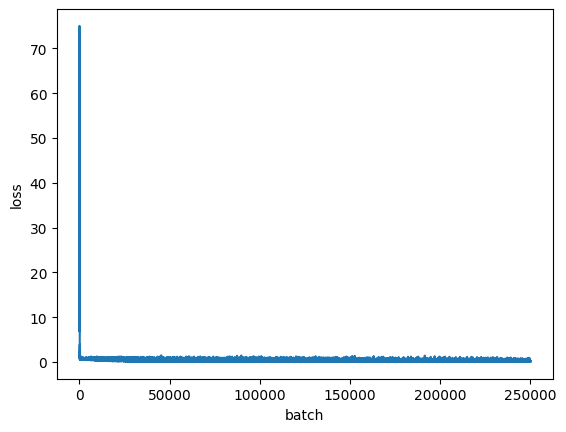

```python
plt.plot(losses)
plt.xlabel('batch')
plt.ylabel('loss')
plt.show()
```

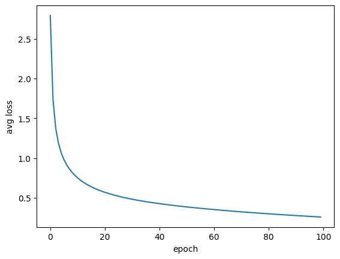

```python
plt.plot(avg_losses)
plt.xlabel('epoch')
plt.ylabel('avg loss')
plt.show()
```

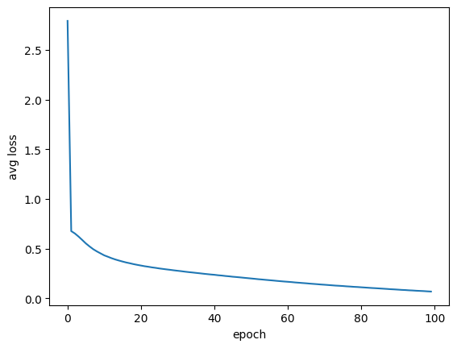

```python
plt.plot(avg_losses_epochs)
plt.xlabel('epoch')
plt.ylabel('avg loss')
plt.show()
```

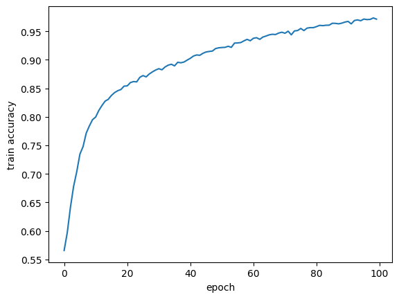

```python
plt.plot(train_accuracies)
plt.xlabel('epoch')
plt.ylabel('train accuracy')
plt.show()
```

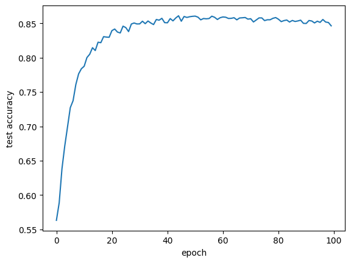

```python
plt.plot(test_accuracies)
plt.xlabel('epoch')
plt.ylabel('test accuracy')
plt.show()
```

```python
from sklearn.metrics import classification_report

print(classification_report(torch_network(torch.Tensor(X_test.toarray())).round().detach().numpy(), y_test.values))
```

```
              precision    recall  f1-score   support

         0.0       0.81      0.87      0.84      4713
         1.0       0.88      0.82      0.85      5287

    accuracy                           0.85     10000
   macro avg       0.85      0.85      0.85     10000
weighted avg       0.85      0.85      0.85     10000
```

### Weights of the network

#### What happens if all the weights are set to zero?

Initializing all the weights in a neural network to zero is generally not recommended because it can lead to issues during training and result in a network that fails to learn effectively. Here's why:

When all the weights are initialized to zero, each neuron in the network will produce the same output during forward propagation. This symmetry in weight initialization will cause the neurons to have the same gradients during backpropagation, leading to identical weight updates. As a result, the neurons will continue to produce the same output in subsequent iterations, resulting in no meaningful learning or differentiation between the neurons.

Additionally, during backpropagation, the gradients with respect to the weights are computed by multiplying the error signal with the input values. When all the weights are initialized to zero, the gradients for all the weights become zero as well. Consequently, there won't be any weight updates, and the network will not be able to learn from the training data.

To avoid these problems, it is common practice to initialize the weights in a neural network with small random values. Random initialization breaks the symmetry between the neurons and allows them to learn and adapt differently based on the input data. This helps in achieving diverse representations and effective learning throughout the network.

There are various initialization techniques available, such as Xavier initialization and He initialization, which aim to set the initial weights to appropriate values that promote efficient training and prevent vanishing or exploding gradients.

In summary, initializing all the weights to zero in a neural network can hinder learning and lead to symmetry issues. It is crucial to use proper weight initialization techniques to facilitate effective training and enable the network to learn meaningful representations from the data.

### Learning Rate

In machine learning and neural networks, the learning rate is a hyperparameter that determines the step size at which the model's parameters are updated during the training process. It controls how quickly or slowly the model learns from the training data.

When training a machine learning model, the goal is to minimize a loss function that quantifies the difference between the model's predictions and the actual target values. The learning rate influences how much the model's parameters are adjusted in the direction of minimizing the loss function at each iteration.

A higher learning rate means that the parameters are adjusted by larger steps, which can result in faster convergence during training. However, if the learning rate is too high, the model may overshoot the optimal solution and fail to converge or even diverge, leading to unstable training.

Conversely, a lower learning rate means smaller parameter updates, which can slow down the training process. However, a lower learning rate can help the model converge to a more accurate and stable solution by taking smaller, more precise steps toward the optimal parameters.

Setting an appropriate learning rate is crucial for successful model training. It often requires experimentation and tuning to find the optimal value for a given task and dataset. If the learning rate is too high, the loss may oscillate or fail to converge. If it is too low, the model may take a long time to converge or get stuck in suboptimal solutions.

There are various strategies to adapt or schedule the learning rate during training, such as learning rate decay, where the learning rate is reduced over time, or adaptive methods like Adam or RMSprop, which adjust the learning rate based on the gradients and other statistics of the model's parameters.

### Activation Function

In neural networks, an activation function is a mathematical function applied to the output of a neuron or a set of neurons. It introduces non-linearity to the network, allowing it to model complex relationships between inputs and outputs.

The activation function operates on the weighted sum of the inputs to a neuron, also known as the activation or net input, and produces the output or activation value of that neuron. The activation function introduces non-linear transformations to the net input, enabling neural networks to learn and represent non-linear patterns in the data.

There are several commonly used activation functions, including:

1. Sigmoid: The sigmoid activation function is defined as f(x) = 1 / (1 + exp(-x)). It maps the input to a range between 0 and 1, which is useful for binary classification problems or when working with probabilities. However, sigmoid functions suffer from the vanishing gradient problem, which can make training deep neural networks more challenging.
2. Rectified Linear Unit (ReLU): ReLU activation function is defined as f(x) = max(0, x). It returns 0 for negative inputs and passes the positive inputs as they are. ReLU has gained popularity due to its simplicity and effectiveness in mitigating the vanishing gradient problem. It allows faster training and can improve the convergence of neural networks.
3. Hyperbolic tangent (Tanh): The hyperbolic tangent activation function is similar to the sigmoid function but maps the input to a range between -1 and 1. It has stronger gradients than sigmoid, making it less prone to the vanishing gradient problem. Tanh can be useful in hidden layers of a neural network.
4. Softmax: The softmax activation function is commonly used in the output layer of a neural network for multi-class classification tasks. It converts the net input into a probability distribution over multiple classes, ensuring that the sum of the probabilities is 1. Softmax is useful when there are multiple mutually exclusive classes to be predicted.

These are just a few examples of activation functions, and there are other variations and specialized functions used in specific contexts. The choice of activation function depends on the problem domain, network architecture, and the desired properties of the model, such as non-linearity, convergence, or interpretability.

#### Sigmoid Function

The sigmoid activation function is a popular choice in neural networks, defined as $$ Sigmoid(x) = \frac{1}{(1 + e^{-x})} $$ It squashes the input value, x, between 0 and 1, providing a smooth non-linear transformation. The sigmoid function is useful for binary classification tasks or when working with probabilities because it maps the input to a probability-like output. As x approaches negative infinity, the sigmoid output approaches 0, while as x approaches positive infinity, the output approaches 1. However, the sigmoid function suffers from the vanishing gradient problem, which can make training deep neural networks more challenging.

#### Hyperbolic Tangent Function

The hyperbolic tangent (tanh) activation function is similar to the sigmoid function, but it maps the input value, x, to a range between -1 and 1. It is defined as $$ tanh(x) = \frac{(e^{x} - e^{-x})}{(e^{x} + e^{-x})} $$ The tanh function provides a smooth non-linear transformation that is symmetric around the origin, with negative inputs mapped to negative outputs and positive inputs mapped to positive outputs. It has stronger gradients compared to the sigmoid function, making it less prone to the vanishing gradient problem. The tanh function is commonly used in hidden layers of neural networks and can help capture non-linear relationships in the data.

#### Leaky ReLU Function

The leaky ReLU (Rectified Linear Unit) activation function is a variation of the ReLU function that addresses the issue of "dying" neurons. It is defined as $$ Leaky\ ReLU(x) = max(ax, x) $$ Where a is a small constant typically set to a small positive value like 0.01. The leaky ReLU function behaves like the ReLU function for positive inputs, passing them through as they are, but for negative inputs, it introduces a small, non-zero gradient, preventing neurons from becoming completely inactive. This helps to mitigate the dying neuron problem and allows information to flow through the network even for negative inputs. The leaky ReLU activation function is commonly used in deep neural networks and can improve training performance by promoting faster convergence and avoiding dead neurons.

#### Why tanh and sigmoid are not used in hidden layers?

Tanh and sigmoid activation functions, while useful in certain contexts, are not commonly used in hidden layers of deep neural networks due to a few reasons:

1. Vanishing Gradient Problem: Both tanh and sigmoid functions saturate for large positive or negative inputs, resulting in gradients close to zero. As a result, during backpropagation, the gradients can diminish exponentially as they are multiplied across multiple layers, making it difficult for the network to learn and update the weights effectively. This issue is known as the vanishing gradient problem and can hinder the training of deep neural networks.
2. Limited Output Range: Both tanh and sigmoid functions map their inputs to a limited range, with sigmoid mapping values between 0 and 1 and tanh mapping values between -1 and 1. This limited output range can lead to saturation of neurons and slow down the learning process, especially in the case of deep networks where information needs to propagate through multiple layers.
3. Preferable Alternatives: ReLU (Rectified Linear Unit) and its variants, such as Leaky ReLU, have become popular choices for hidden layers in deep neural networks. ReLU functions provide non-linearity, but unlike tanh and sigmoid, they do not saturate for positive inputs, allowing for efficient computation and avoiding the vanishing gradient problem. ReLU-based activation functions also have a wider output range, which helps in better capturing and propagating information through the network.
4. Computational Efficiency: The computation of tanh and sigmoid functions involves more complex mathematical operations compared to ReLU, which primarily requires simple thresholding. This makes ReLU-based activations computationally more efficient, which is especially crucial when dealing with large-scale neural networks and deep architectures.
5. They are not zero-centered: Another problem with sigmoid and Tanh activation functions is that they are not zero-centered. This means that the output of the activation function is always positive, which can make it difficult for the network to learn if the input data has a mean of zero. This can lead to slower convergence and suboptimal solutions.

While tanh and sigmoid functions are still used in certain scenarios, such as binary classification tasks or specific architectures like recurrent neural networks (RNNs), ReLU and its variants have become the default choice for hidden layers in deep learning due to their effectiveness in addressing the vanishing gradient problem, computational efficiency, and better information flow.

#### What's the advantage of Leaky ReLU over ReLU?

The Leaky ReLU (Rectified Linear Unit) activation function offers a few advantages over the standard ReLU function:

1. Avoiding "Dead" Neurons: One limitation of the ReLU function is that once a neuron becomes inactive (outputting zero), it cannot recover during training because the gradient is also zero. In contrast, the Leaky ReLU introduces a small, non-zero gradient for negative inputs, preventing neurons from becoming completely inactive. This helps to address the "dying ReLU" problem and allows information to still flow through the network.
2. Handling Negative Inputs: ReLU sets all negative values to zero, effectively eliminating negative activations. However, this can discard potentially useful information encoded in negative values. With Leaky ReLU, a small negative slope (typically set to a small constant like 0.01) is introduced for negative inputs, allowing the network to retain and propagate negative information that might be relevant for learning.
3. Better Gradient Flow: Leaky ReLU generally exhibits a more continuous and gradient-friendly behavior compared to ReLU. While ReLU has a sharp transition at zero, Leaky ReLU has a smoother transition. This smoothness can help with the training process by providing more consistent and continuous gradients, which in turn facilitates better backpropagation and weight updates.
4. Reduced Variance Shift: Another potential issue with ReLU is that it can cause a shift in the mean activation of neurons over time, as it sets negative values to zero. This phenomenon is known as "variance shift." Leaky ReLU mitigates this issue by allowing small negative values, helping to maintain a more stable mean activation across the network.

These advantages make Leaky ReLU a popular choice for activation functions in deep neural networks, particularly when dealing with architectures where ReLU may exhibit limitations.

### Batch Size

#### Why we use batches in training a neural network?

Using batches in training a neural network, known as batch training or mini-batch training, offers several advantages:

1. Efficiency in Memory and Computation: Training a neural network on the entire dataset at once can be computationally expensive and memory-intensive, especially when working with large datasets. By dividing the dataset into smaller batches, it becomes more feasible to load and process them in memory. The computations can be parallelized, taking advantage of the capabilities of modern hardware, such as GPUs, to speed up the training process.
2. More Stable Gradient Estimates: Batch training provides a more stable estimate of the gradient compared to stochastic gradient descent (SGD), where the gradients are computed on individual data points. By aggregating gradients over a batch, the noisy and erratic updates from individual data points are smoothed out. This stability helps the optimization process by providing a more reliable estimate of the direction and magnitude of weight updates.
3. Improved Generalization: Mini-batch training offers a balance between full-batch training (using the entire dataset) and stochastic gradient descent (SGD). Full-batch training can sometimes overfit to the training data, while SGD can exhibit high variance due to the noisy gradient estimates from individual data points. Mini-batch training strikes a balance by capturing the general trends present in the data while introducing enough noise to avoid overfitting. It can lead to better generalization and performance on unseen data.
4. Regularization Effects: The mini-batch approach can be seen as a form of regularization due to the noise introduced by randomly sampling a subset of the data. This noise can help prevent the network from overfitting and improve its ability to generalize to unseen examples.
5. Learning Dynamics: Batches provide a smoother learning trajectory compared to SGD, where the weights are updated after every single data point. The learning dynamics of mini-batch training tend to be more consistent and predictable, allowing for better control over the optimization process and convergence behavior.

These benefits make batch training a common approach in deep learning, striking a balance between computational feasibility and effective optimization.

#### What's the difference between using large or small batch size?

The choice of batch size in training a neural network can have an impact on the training dynamics and performance. Here are the differences and advantages of using large and small batch sizes:

**Large Batch Size**:

1. Computational Efficiency: With a large batch size, the computations can be parallelized more efficiently, especially when using hardware accelerators like GPUs. This can result in faster training times, as the operations can be performed in parallel across the batch.
2. Smoothed Gradient Estimates: A larger batch size provides a more stable estimate of the gradient because it aggregates the gradients of multiple samples. The noise and fluctuations from individual data points are averaged out, resulting in smoother updates and potentially more reliable optimization.
3. Generalization Performance: Large batch sizes can potentially lead to better generalization performance, especially when the dataset is diverse and representative. The aggregated gradients over a large batch capture the overall trends of the data, helping the model generalize better to unseen examples.
4. Memory Limitations: Large batch sizes require more memory to store the batch and intermediate computations during training. If the available memory is limited, using larger batch sizes may not be feasible.

**Small Batch Size**:

1. Improved Convergence: Smaller batch sizes can lead to faster convergence during training. The updates are more frequent, allowing the model to adapt to the data more rapidly and potentially find better minima in the optimization landscape.
2. Regularization Effects: Using smaller batch sizes introduces more noise into the training process, similar to a form of regularization. This noise can help prevent overfitting and improve the generalization ability of the model.
3. Local Optima Exploration: Smaller batch sizes allow the model to explore different regions of the optimization landscape more effectively. By updating the weights more frequently, the model has the opportunity to escape local optima and potentially find better solutions.
4. Increased Variance: Smaller batch sizes exhibit higher variance in the gradient estimates due to the limited number of samples. This higher variance can lead to more noisy updates and slower convergence if not compensated by other techniques, such as learning rate adjustments.
5. Computational Overhead: Training with small batch sizes can be computationally expensive, especially if hardware accelerators are not fully utilized. The parallelization efficiency decreases as the batch size reduces, potentially resulting in longer training times.

The choice of batch size depends on various factors, including the dataset size, computational resources, optimization landscape, and the specific problem at hand. Large batch sizes offer computational efficiency and stable gradient estimates, while small batch sizes can lead to faster convergence, better exploration of optima, and regularization effects. It is common practice to experiment with different batch sizes to find the optimal trade-off between computational efficiency and model performance.